# Assignment 3

The Markdown Mates

Some Key Details

Rooms: Number of rooms

Price: Price in dollars

Type: h - house,cottage,villa, semi,terrace; u - unit, duplex; t - townhouse;

Distance: Distance from CBD

Bedroom2: Scraped # of Bedrooms (from different source)

Bathroom: Number of Bathrooms

### Initially reading data

```r
houses <- read_csv("Melbourne_housing_FULL.csv")
housesTarget <- houses[,c("Price", "Rooms", "Type", "Distance", "Bedroom2", "Bathroom")]
```

# Dealing with Missing Values

Create a missing values summary Diagrams to visualise the data

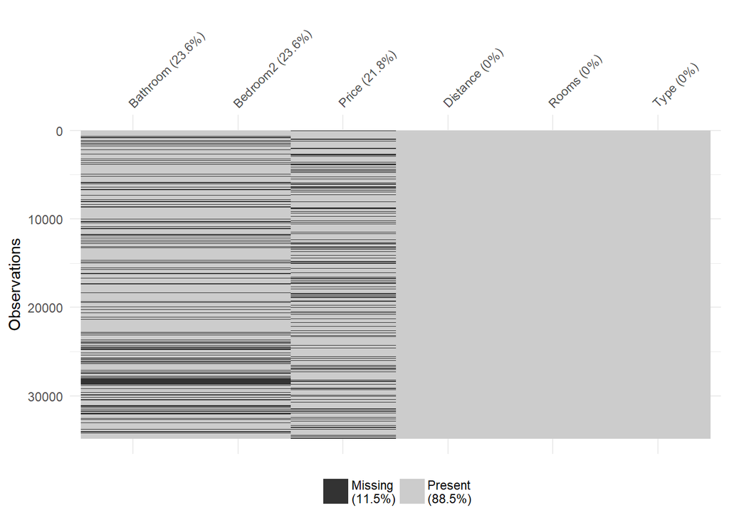

```r
vis_miss(housesTarget, sort_miss=TRUE)
```

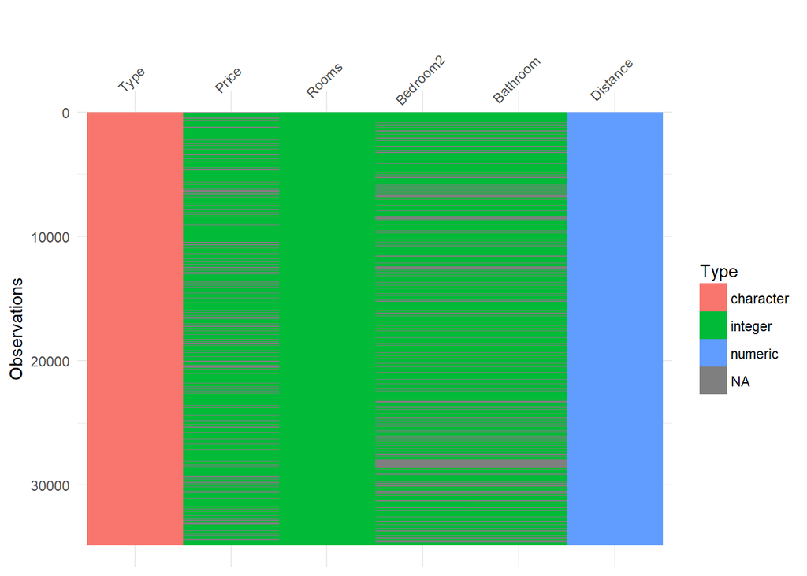

```r
vis_dat(housesTarget)
```

Various missing value summaries to further understand what values are missing

```r
house_miss <- miss_summary(housesTarget)
house_miss$miss_case_table
```

```
## [[1]]
## # A tibble: 4 x 3
##   n_miss_in_case n_cases pct_miss
##            <int>   <int>    <dbl>
## 1              0   20800    59.7
## 2              1    5837    16.7
## 3              2    6443    18.5
## 4              3    1777     5.10
```

```r
house_miss$miss_var_summary
```

```
## [[1]]
## # A tibble: 6 x 4
##   variable n_miss pct_miss n_miss_cumsum
##   <chr>     <int>    <dbl>         <int>
## 1 Price      7610 21.8              7610
## 2 Rooms         0  0.               7610
## 3 Type          0  0.               7610
## 4 Distance      1  0.00287          7611
## 5 Bedroom2   8217 23.6             15828
## 6 Bathroom   8226 23.6             24054
```

Shows that 1777 observations are missing 3 variables, these observations should be removed, since 50% of the data assosciated with these observations is not valid.

```r
housesTarget <- housesTarget[-which(rowMeans(is.na(housesTarget)) >= 0.5),]
#Check missing value summaries again
house_miss <- miss_summary(housesTarget)
house_miss$miss_case_table
```

```
## [[1]]
## # A tibble: 3 x 3
##   n_miss_in_case n_cases pct_miss
##            <int>   <int>    <dbl>
## 1              0   20800     62.9
## 2              1    5837     17.6
## 3              2    6443     19.5
```

Plot data in scatter plots to visualise missing data

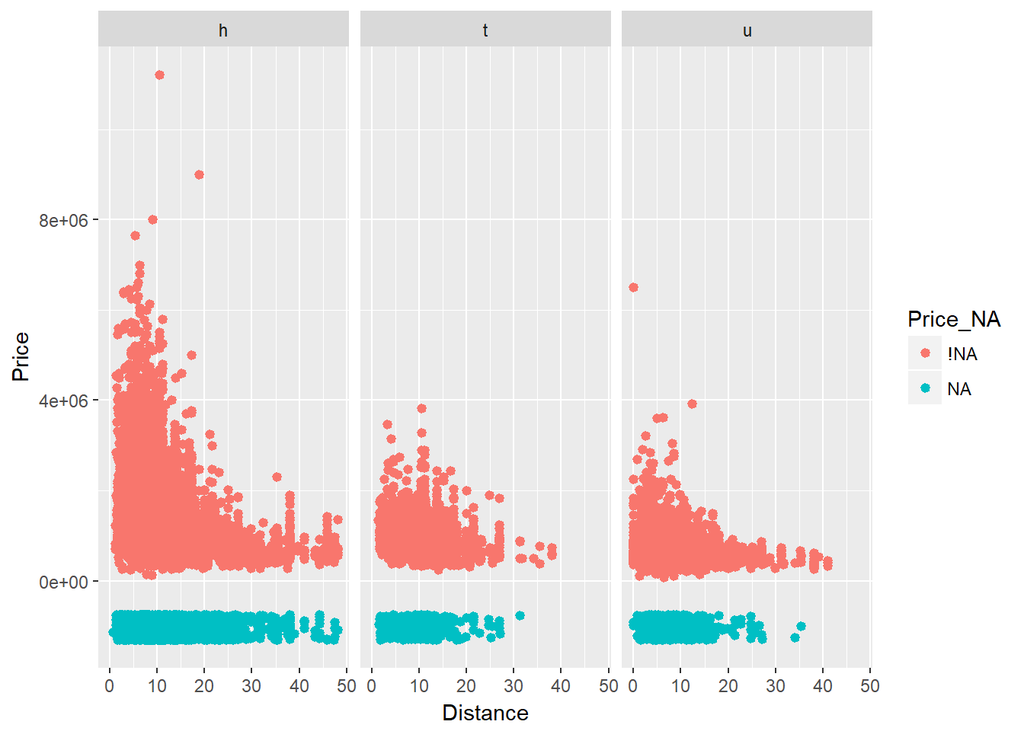

```r
#Create Shadow matrix to indicate missing data
tao_shadow <- bind_shadow(housesTarget)

ggplot(tao_shadow, aes(x = Distance, y = Price, colour = Price_NA)) + geom_point() + geom_miss_point()+ facet_wrap(~Type)
```

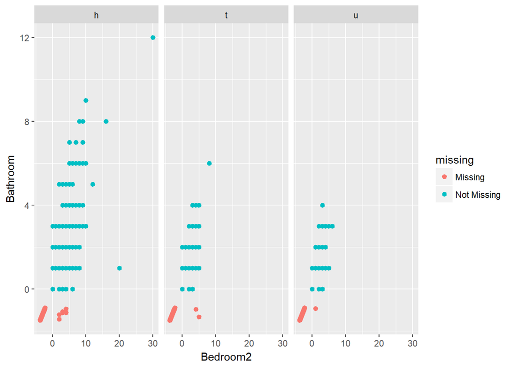

```r
ggplot(tao_shadow, aes(x = Bedroom2, y = Bathroom)) + geom_point() + geom_miss_point()+ facet_wrap(~Type)
```

Imputation, now using a simpler mean value method, separated by type

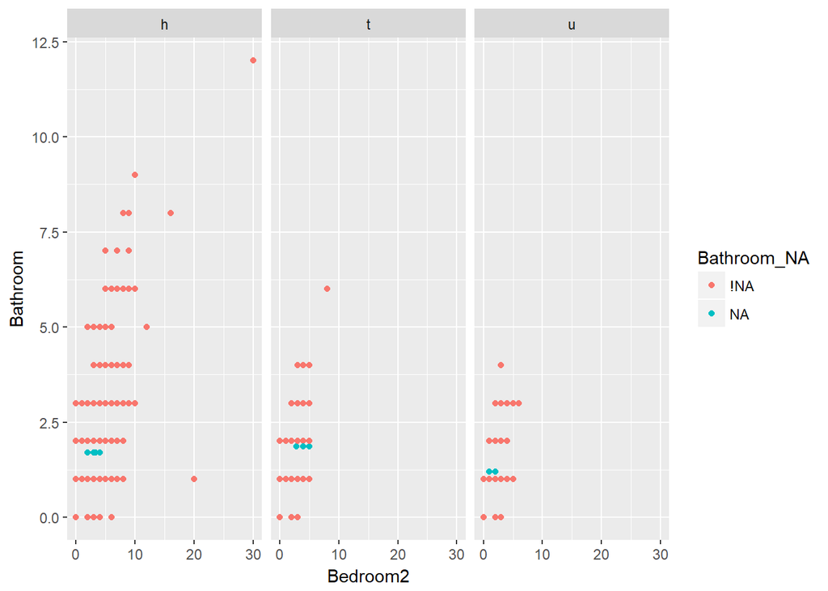

```r
#Start with house data
tao_house <- tao_shadow %>%
  filter(Type == "h") %>%
  mutate(Bathroom = ifelse(is.na(Bathroom),
                        mean(Bathroom, na.rm = TRUE),
                        Bathroom),
         Bedroom2 = ifelse(is.na(Bedroom2),
                        mean(Bedroom2, na.rm = TRUE),
                        Bedroom2))

#Townhouse data
tao_town <- tao_shadow %>%
  filter(Type == "t") %>%
  mutate(Bathroom = ifelse(is.na(Bathroom),
                        mean(Bathroom, na.rm = TRUE),
                        Bathroom),
         Bedroom2 = ifelse(is.na(Bedroom2),
                        mean(Bedroom2, na.rm = TRUE),
                        Bedroom2))

#Unit data
tao_unit <- tao_shadow %>%
  filter(Type == "u") %>%
  mutate(Bathroom = ifelse(is.na(Bathroom),
                        mean(Bathroom, na.rm = TRUE),
                        Bathroom),
         Bedroom2 = ifelse(is.na(Bedroom2),
                        mean(Bedroom2, na.rm = TRUE),
                        Bedroom2))

#Combining data and plotting
tao_shadow <- bind_rows(tao_house, tao_town, tao_unit)
ggplot(tao_shadow, aes(x = Bedroom2, y = Bathroom, colour = Bathroom_NA)) + geom_point() + facet_wrap(~Type)
```

Check missing values now

```r
housesTarget$Bedroom2 <- tao_shadow$Bedroom2
housesTarget$Bathroom <- tao_shadow$Bathroom
tao_shadow <- bind_shadow(housesTarget)
house_miss <- miss_summary(tao_shadow)
house_miss$miss_case_table
```

```
## [[1]]
## # A tibble: 2 x 3
##   n_miss_in_case n_cases pct_miss
##            <int>   <int>    <dbl>
## 1              0   27246     82.4
## 2              1    5834     17.6
```

```r
house_miss$miss_var_summary
```

```
## [[1]]
## # A tibble: 12 x 4
##    variable    n_miss pct_miss n_miss_cumsum
##    <chr>        <int>    <dbl>         <int>
##  1 Price         5834     17.6          5834
##  2 Rooms            0      0.           5834
##  3 Type             0      0.           5834
##  4 Distance         0      0.           5834
##  5 Bedroom2         0      0.           5834
##  6 Bathroom         0      0.           5834
##  7 Price_NA         0      0.           5834
##  8 Rooms_NA         0      0.           5834
##  9 Type_NA          0      0.           5834
## 10 Distance_NA      0      0.           5834
## 11 Bedroom2_NA      0      0.           5834
## 12 Bathroom_NA      0      0.           5834
```

Impute Price data using the Bioconductor Impute Method, separating by property type

```r
#First House data
tao_impute_house <- bind_shadow(housesTarget)%>%
  arrange(Type, Rooms, Distance, Price) %>%
  filter(Type == "h") %>%
  select(Price, Distance, Rooms)
tao_impute_house <- impute.knn(as.matrix(tao_impute_house), 1)
```

[output not shown]

[output cut: 8 more lines]

[output not shown]

```r
#Next Townhouse data
tao_impute_town <- bind_shadow(housesTarget) %>%
  arrange(Type,Rooms, Distance, Price) %>%
  filter(Type == "t") %>%
  select(Price, Distance, Rooms)
tao_impute_town <- impute.knn(as.matrix(tao_impute_town), 1)
```

```
## Cluster size 3230 broken into 1929 1301
## Cluster size 1929 broken into 1485 444
## Done cluster 1485
## Done cluster 444
## Done cluster 1929
## Done cluster 1301
```

```r
#Finally Unit data
tao_impute_unit <- bind_shadow(housesTarget) %>%
  arrange(Type, Rooms, Distance, Price) %>%
  filter(Type == "u") %>%
  select(Price, Distance, Rooms)
tao_impute_unit <- impute.knn(as.matrix(tao_impute_unit), 1)
```

```
## Cluster size 6688 broken into 3495 3193
## Cluster size 3495 broken into 3024 471
## Cluster size 3024 broken into 1149 1875
## Done cluster 1149
## Cluster size 1875 broken into 920 955
## Done cluster 920
## Done cluster 955
## Done cluster 1875
## Done cluster 3024
## Done cluster 471
## Done cluster 3495
## Cluster size 3193 broken into 2397 796
## Cluster size 2397 broken into 962 1435
## Done cluster 962
## Done cluster 1435
## Done cluster 2397
## Done cluster 796
## Done cluster 3193
```

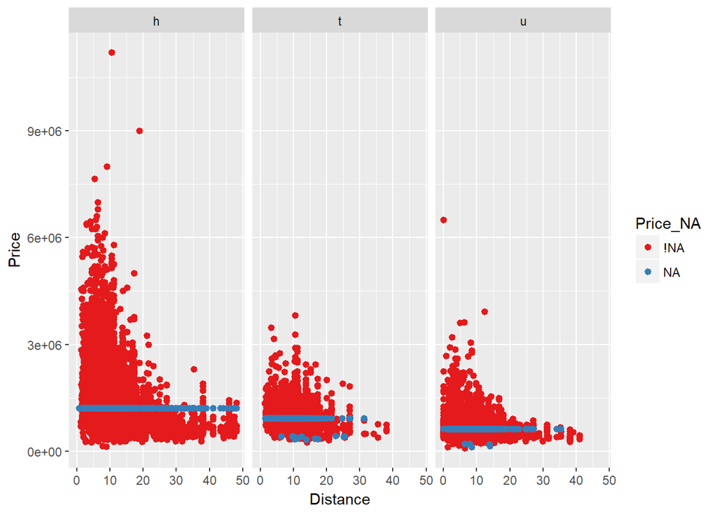

```r
#Combine all imputations
tao_impute <- rbind(tao_impute_house$data, tao_impute_town$data, tao_impute_unit$data)

#Transfer imputations to shadow matrix
tao_shadow <- bind_shadow(housesTarget) %>%
  arrange(Type, Rooms, Distance, Price) %>%
  mutate(Price = tao_impute[,1],
         Distance = tao_impute[,2])


#Plot outcomes
ggplot(tao_shadow, aes(x = Distance, y = Price, colour = Price_NA)) + geom_point(alpha = 0.25) + facet_wrap(~Type) + scale_colour_brewer(palette="Set1") + geom_miss_point()
```

Check missing values now

```r
house_miss <- miss_summary(tao_shadow)
house_miss$miss_case_table
```

```
## [[1]]
## # A tibble: 1 x 3
##   n_miss_in_case n_cases pct_miss
##            <int>   <int>    <dbl>
## 1              0   33080     100.
```

```r
house_miss$miss_var_summary
```

```
## [[1]]
## # A tibble: 12 x 4
##    variable    n_miss pct_miss n_miss_cumsum
##    <chr>        <int>    <dbl>         <int>
##  1 Price            0       0.             0
##  2 Rooms            0       0.             0
##  3 Type             0       0.             0
##  4 Distance         0       0.             0
##  5 Bedroom2         0       0.             0
##  6 Bathroom         0       0.             0
##  7 Price_NA         0       0.             0
##  8 Rooms_NA         0       0.             0
##  9 Type_NA          0       0.             0
## 10 Distance_NA      0       0.             0
## 11 Bedroom2_NA      0       0.             0
## 12 Bathroom_NA      0       0.             0
```

Defining new dataframe with all missing values replaced using aforementioned imputation methods

```r
HousingNoNA <- tao_shadow[,c(1:6)]
```

# Summary Plots of house price against other variables

Finding the mean price of the different types of houses and plotting them.

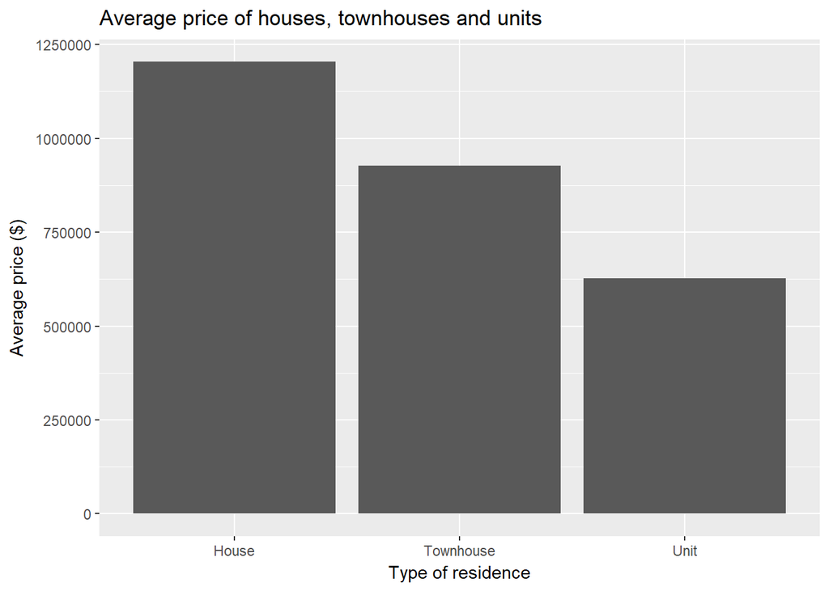

```r
tao_shadow_av <- tao_shadow %>%
     group_by(Type) %>%
     summarise(Price=mean(Price))
ggplot(data = tao_shadow_av) + geom_col(mapping = aes(Type, Price)) + ggtitle("Average price of houses, townhouses and units") + labs(y="Average price ($)", x = "Type of residence") + scale_x_discrete(labels=c("h" = "House", "t" = "Townhouse","u" = "Unit"))
```

This plot shows that the mean price of houses is $1,203,740, the mean price of townhouses is $927,598, and the mean price of units is $627,345.

Finding the mean price of the different number of rooms and plotting them against price.

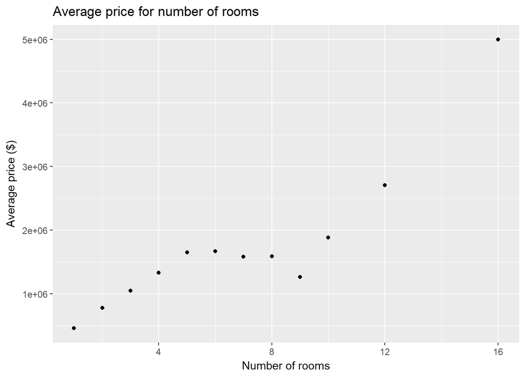

```r
tao_shadow_av_room <- tao_shadow %>%
     group_by(Rooms) %>%
     summarise(Price=mean(Price))
ggplot(data = tao_shadow_av_room) + geom_point(mapping = aes(Rooms, Price)) + ggtitle("Average price for number of rooms") + labs(y="Average price ($)", x = "Number of rooms")
```

This plot shows that the mean price increases as rooms increase upto 5 rooms, after that it actually platos, then falls. After 10 rooms price of the home exponentially rises.

Plotting average price of house type, against distance from CBD

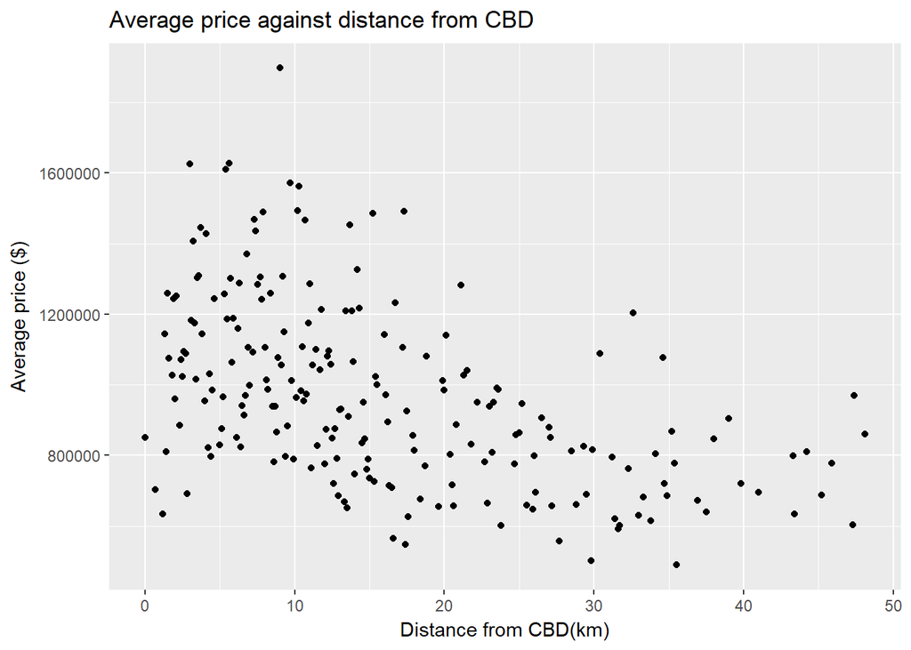

```r
tao_shadow_av_distance <- tao_shadow %>%
     group_by(Distance) %>%
     summarise(Price=mean(Price))
ggplot(data = tao_shadow_av_distance) + geom_point(mapping = aes(Distance, Price)) + ggtitle("Average price against distance from CBD") + labs(y="Average price ($)", x = "Distance from CBD(km)")
```

This plot indicates that a negative negative relationship exists between distance and average price of house type, with prices falling as the houses move further from the CBD.

# Model Construction for house prices

In constructing the best model for predicting house price, the first step was to determine which explanatory variables were jointly signficant in explaining price; with the explanatory variables being Rooms, Type, Distance, Bedroom2 and Bathroom. The optimal model for predicting house prices will have the best fit, with measures of goodness of fit given by R-squared, adjusted R-squared and BIC, when comparing models.

```r
#Modelling price against all explanatory variables to establish significance, and removing intercept to improve model accuracy.
price_variables<- lm(Price~Rooms+Type+Distance+Bedroom2+Bathroom-1, data=HousingNoNA)
tidy(price_variables)
```

```
##       term  estimate  std.error  statistic       p.value
## 1    Rooms 246294.82  3305.4475  74.511791  0.000000e+00
## 2    Typeh 740449.15 14806.2948  50.009078  0.000000e+00
## 3    Typet 528863.46 15778.4348  33.518119 3.008598e-242
## 4    Typeu 373876.98 12791.6074  29.228303 1.945560e-185
## 5 Distance -30123.88   404.3447 -74.500482  0.000000e+00
## 6 Bedroom2  -4196.03  3623.3310  -1.158059  2.468484e-01
## 7 Bathroom  10808.45  5080.8757   2.127281  3.340413e-02
```

```r
HousingNoNA <- HousingNoNA %>%
  mutate(rooms_sqr = Rooms^2) %>%
  mutate(distance_sqr = Distance^2) %>%
  mutate(rooms_cube = Rooms^3) %>%
  mutate(distance_cube = Distance^3)
price_variables_interactions_transformations<- lm(Price~Rooms*Type*Distance + rooms_sqr + distance_sqr + rooms_cube + distance_cube + Rooms + Distance + Type - 1, data=HousingNoNA)
tidy(price_variables_interactions_transformations)
```

```
##                    term      estimate    std.error   statistic
## 1                 Rooms  3.550404e+05 26277.352770  13.5112703
## 2                 Typeh  5.985541e+05 41861.751679  14.2983524
## 3                 Typet  5.111784e+05 87218.878586   5.8608689
## 4                 Typeu  1.691321e+05 36450.740265   4.6400190
## 5              Distance -3.144544e+04  3070.077986 -10.2425535
## 6             rooms_sqr  9.797391e+03  5325.887129   1.8395791
## 7          distance_sqr  1.064524e+03   154.041214   6.9106473
## 8            rooms_cube -6.657388e+02   310.735276  -2.1424631
## 9         distance_cube  8.738654e-01     2.553587   0.3422110
## 10          Rooms:Typet -1.282115e+05 30918.818810  -4.1467135
## 11          Rooms:Typeu -4.522616e+04 19574.100354  -2.3105103
## 12       Rooms:Distance -1.206995e+04   542.641130 -22.2429737
## 13       Typet:Distance -1.027783e+04  7563.077004  -1.3589479
## 14       Typeu:Distance  2.263685e+04  4402.854843   5.1414032
```

[output cut: 19 more lines]

```r
price_refinedmodel<- lm(Price~Rooms*Type*Distance + rooms_sqr + distance_sqr + rooms_cube + Rooms + Type + Distance - 1, data=HousingNoNA)
tidy(price_refinedmodel)
```

```
##                    term     estimate   std.error   statistic       p.value
## 1                 Rooms  355161.0579 26274.63701  13.5172584  1.595100e-41
## 2                 Typeh  601200.4817 41140.70734  14.6132753  3.268581e-48
## 3                 Typet  513023.6581 87050.87760   5.8933772  3.820439e-09
## 4                 Typeu  170642.7567 36181.97396   4.7162368  2.412266e-06
## 5              Distance  -32218.0199  2080.48598 -15.4858145  6.691646e-54
## 6             rooms_sqr    9807.5815  5325.73277   1.8415459  6.555055e-02
## 7          distance_sqr    1116.0116    33.04823  33.7691831 8.496816e-246
## 8            rooms_cube    -666.6044   310.72083  -2.1453483  3.193227e-02
## 9           Rooms:Typet -127875.2935 30902.79486  -4.1379847  3.512361e-05
## 10          Rooms:Typeu  -44938.4368 19555.77375  -2.2979626  2.157013e-02
## 11       Rooms:Distance  -12077.4889   542.18680 -22.2755128 4.062758e-109
## 12       Typet:Distance  -10204.2179  7559.91663  -1.3497792  1.770961e-01
## 13       Typeu:Distance   22795.9952  4378.16779   5.2067432  1.933322e-07
## 14 Rooms:Typet:Distance   11644.8776  2592.96898   4.4909437  7.114794e-06
## 15 Rooms:Typeu:Distance   -1279.4078  1799.99943  -0.7107823  4.772242e-01
```

```r
glance(price_refinedmodel)
```

```
##   r.squared adj.r.squared    sigma statistic p.value df    logLik      AIC
## 1 0.8538219     0.8537556 463822.7  12875.45       0 15 -478534.3 957100.5
##      BIC     deviance df.residual
## 1 957235 7.113324e+15       33065
```

The final model was then augmented to predict/fit prices using the data provided in the modified dataframe, HousingNoNA. Residuals for the predicted or fitted values were also plotted.

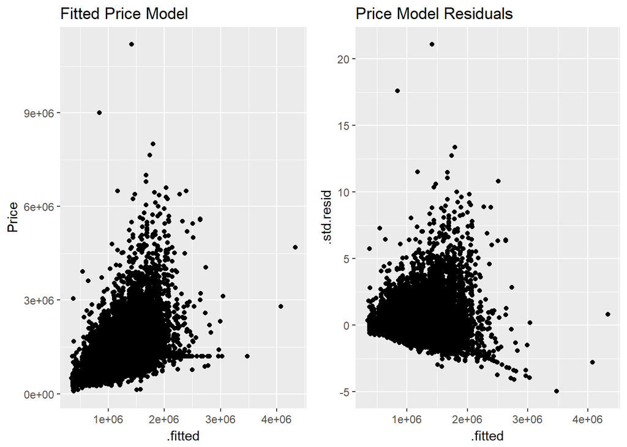

```r
price_model <- augment(price_refinedmodel, HousingNoNA)
predicted <- ggplot(price_model, aes(x=.fitted, y=Price)) + geom_point() + ggtitle("Fitted Price Model")
residuals <- ggplot(price_model, aes(x=.fitted, y=.std.resid)) + geom_point() + ggtitle("Price Model Residuals")
grid.arrange(predicted,residuals, ncol=2)
```